# Sheet07

## Loading Necessary Packages

```r
library(tidyverse)
library(infer)
```

## a) Creating a dataframe

```r
nearsightedness <- c(rep("yes", 21), rep("no", 194-21))
df <- data.frame(nearsightedness)
as_tibble(df)
```

```
## # A tibble: 194 x 1
##    nearsightedness
##    <chr>
##  1 yes
##  2 yes
##  3 yes
##  4 yes
##  5 yes
##  6 yes
##  7 yes
##  8 yes
##  9 yes
## 10 yes
## # ... with 184 more rows
```

## b) Runnning the command

```r
table(df)
```

```
## df
##  no yes
## 173  21
```

## c) Null and Alternative Hypothesis

*Null Hypothesis:* Nearsightness affect 8% of the childreen. In other words, the data provides no evidence about the inaccuracy of the 8% value.The data differ from the 8% value due to chance.
$$H_{0}: μ_{x} = 8\%$$

*Alternative Hypothesis:* Nearsightness affect more then 8% of the childreen. In other words, the data provides evidence that the 8% is inaccurate.The data doesn’t differ from the 8% value due to chance.
$$H_{a}: μ_{x} > 8\%$$

## d) Null Distributions based on 1000 resamples

```r
set.seed(12345)
null_distn <- df %>%
  specify(response = nearsightedness, success = "yes") %>%
  hypothesize(null = "point", p = 0.08) %>%
  generate(reps = 1000) %>%
  calculate(stat = "prop")
null_distn
```

```
## # A tibble: 1,000 x 2
##    replicate   stat
##    <fct>      <dbl>
##  1 1         0.113
##  2 2         0.0876
##  3 3         0.0464
##  4 4         0.108
##  5 5         0.0309
##  6 6         0.0722
##  7 7         0.0928
##  8 8         0.113
##  9 9         0.0928
## 10 10        0.0567
## # ... with 990 more rows
```

## e) Testing Null Hypothesis (from exercise (c))

```r
p_value <- null_distn %>%
  get_pvalue(obs_stat = 21/194, direction = "greater")
p_value
```

```
## # A tibble: 1 x 1
##   p_value
##     <dbl>
## 1   0.099
```

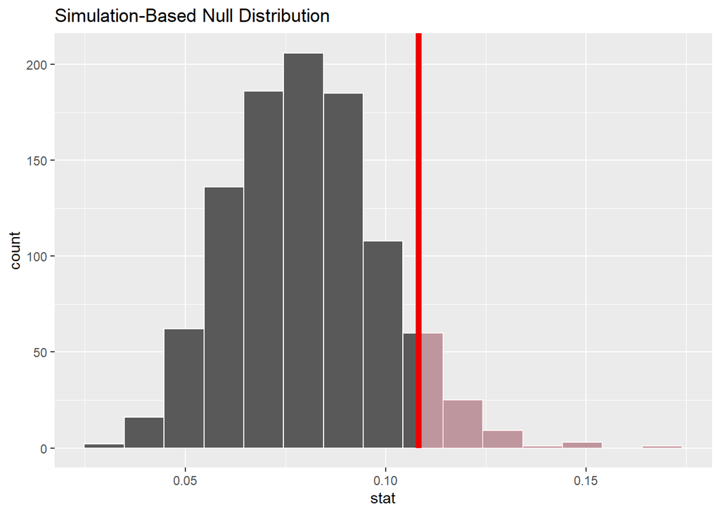

```r
null_distn %>%
  visualize() +
  shade_p_value(obs_stat = 21/194, direction = "greater")
```

```r
significance_level <- 0.05
```

## f) Conclusion

If the p-value is less than or equal to the significance level, the null hypothesis is rejected.

```r
p_value <= significance_level
```

```
##      p_value
## [1,]   FALSE
```

Since the statement above does not hold, one must say that there is NOT sufficient evidence to reject the Null Hypothesis.Going back to the question: `Do these data provide evidence that the 8% value is inaccurate?` We can not exclude, that the data doesn’t provide any evidence about the inaccuracy of the 8% value. Our observed data might differ due to chance. This means, we have no evidence whether the statement `It is believed that near-sightedness affects about 8% of all children.` is inaccurate.